# Arbeidskrav 3

IJ

2022-11-10

I denne oppgaven simulerer vi en populasjon ut fra gitte observasjoner. Ut fra denne populasjonen gjør vi tilfeldige utvalg (samples) og gjør statistiske beregninger og analyse.

Verdiene kan regenes som den mulige forskjellen mellom to intervensjoner (Behandling - Kontroll) i et cross-over studie hvor deltagerne har gjennomført begge intervensjoner.

Vi simulerer en populasjon på en million, hvor gjennomsnittet (mean) er på 1.5 og standardavviket (SD) på 3. Ut av denne trekker vi to utvalg. Et av studiene har et utvalg (n) på 8 (samp1) og det andre på 40 (samp2). Ut fra disse, lager vi en lineær model og lagrer objektene som m1 og m2:

Utvalg 1 - samp1

```
##
## Call:
## lm(formula = y ~ 1, data = samp1)
##
## Residuals:
##     Min      1Q  Median      3Q     Max
## -6.5322 -1.2523 -0.0883  1.3540  4.8692
##
## Coefficients:
##             Estimate Std. Error t value Pr(>|t|)
## (Intercept)    1.840      1.251    1.47    0.185
##
## Residual standard error: 3.539 on 7 degrees of freedom
```

Utvalg 2 - samp2

```
##
## Call:
## lm(formula = y ~ 1, data = samp2)
##
## Residuals:
##     Min      1Q  Median      3Q     Max
## -5.6557 -2.2883  0.2636  2.2549  6.4212
##
## Coefficients:
##             Estimate Std. Error t value Pr(>|t|)
## (Intercept)   1.5642     0.4774   3.276  0.00221 **
## ---
## Signif. codes:  0 '***' 0.001 '**' 0.01 '*' 0.05 '.' 0.1 ' ' 1
##
## Residual standard error: 3.019 on 39 degrees of freedom
```

# Oppgave 1.

“Estimatet” er et beregnet gjennomsnitt av alle verdier i utvalget. I våre beregniner er estimatet 1.840 for samp1 og 1.564 for samp2. Hvor godt et slikt estaimat er, avhenger av hvor hvor mye fordelingen X˜ er spredt rundt µ (populasjonens mean). Våre undersøkelser viser at utvalg 2 har et lavere estimat, og er derfor mer presis.

Standard Error (SE) er definert som standard deviasjonen (SD), delt på kvadratroten av antall observasjoner (n). SE er en måte å angi feilmarginen av en måling eller et estimat. I vår oppgave er SE 1.251 for samp1 og 0.477 for samp2. Vi ser da at et større utvalg som i samp2 gir en mindre SE. Dette indikerer en mindre feilmargin på estimatet.

P-verdien et statistisk mål, som brukes for å avgjøre hvilken av to motstridende påstander vi skal støtte i en statistisk hypotesetesting. Det forteller oss om sannsynligheten for at testresultatet er det samme, eller mer ekstremt om nullhypotesen er sann. P-verdien er et tall mellom 0 og 1. Jo lavere verdi, jo mindre forenlig er våre observasjoner med nullypotesen. Om p-verdien er under det signifikansnivå vi har satt (typisk 5%), vil man si at testen er signifikant.

# Oppgave 2.

De to studiene har ulik utvalgstørrelse. Når vi benytter utvalg av en simulert populasjon, er det da viktig at utvalgene ikke blir for små.

# Oppgave 3.

# Oppgave 4.

Beregner SE og gjennomsnitlig SE for samp1 og samp2

| Simple size | SD of estimate | Average of SE |
| --- | --- | --- |
| 8 | 1.0708432 | 1.0213745 |
| 40 | 0.4838475 | 0.4696954 |

Abbrivations: SD, standarddeviation

Som vist er SD og gjennomsnitt av SE for henholdsvis sample8 og sample40 svært like.

# Oppgave 5.

Lager et histogram av p-verdier fra hvert av de to studie-utvalgene.

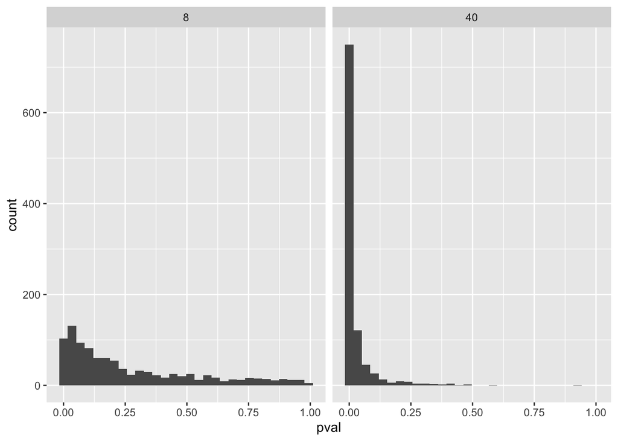

I samp1 er p-verdiene spredt fra 0-1, med en lett opphopning ned mot 0. I samp2 er det en overvekt p-verdier ned mot 0. Dette kan tolkes som at det er flere tester i samp2 med statistisk signifikans og at den statistiske styrken er høyere.

# Oppgave 6.

Beregner antall studier fra hvert utvalg som viser en statistisk signifikant effekt.

```
## # A tibble: 2 × 2
##       n sig_results
##   <dbl>       <dbl>
## 1     8       0.227
## 2    40       0.865
```

Som vi ser er det stor forskjell mellom de to utvalgene. Vi har valgt en konfidensintervall på 95%. I utvalg 1 er det kun 22,7 % av studiene som viser signifikant forskjell. I utvalg 2 er det 86,5% av studiene som viser signifikant forskjell.

# Oppgave 7.

```
##
##      One-sample t test power calculation
##
##               n = 8
##               d = 0.5
##       sig.level = 0.05
##           power = 0.232077
##     alternative = two.sided
```

```
##
##      One-sample t test power calculation
##
##               n = 40
##               d = 0.5
##       sig.level = 0.05
##           power = 0.8693981
##     alternative = two.sided
```

Den beregnede styrken er på henholdsvis 0.232 for utvalg 1 og 0.869 for utvalg 2. Den statistsike styrken forteller oss sannsynligheten for at resultatet av studiene er statistisk signifikant. Ofte definerer vi at dette skal være minimum 0.8 eller 80%. I våre beregninger er derfor utvalget med 40 innenfor den ønskede statisske styrke.

Simulerer studier uten populasjonseffekt

# Oppgave 8.

Lager nye histogram for datasett med fra studier av en populasjon hvor den gjennomsnittlige effekten er null

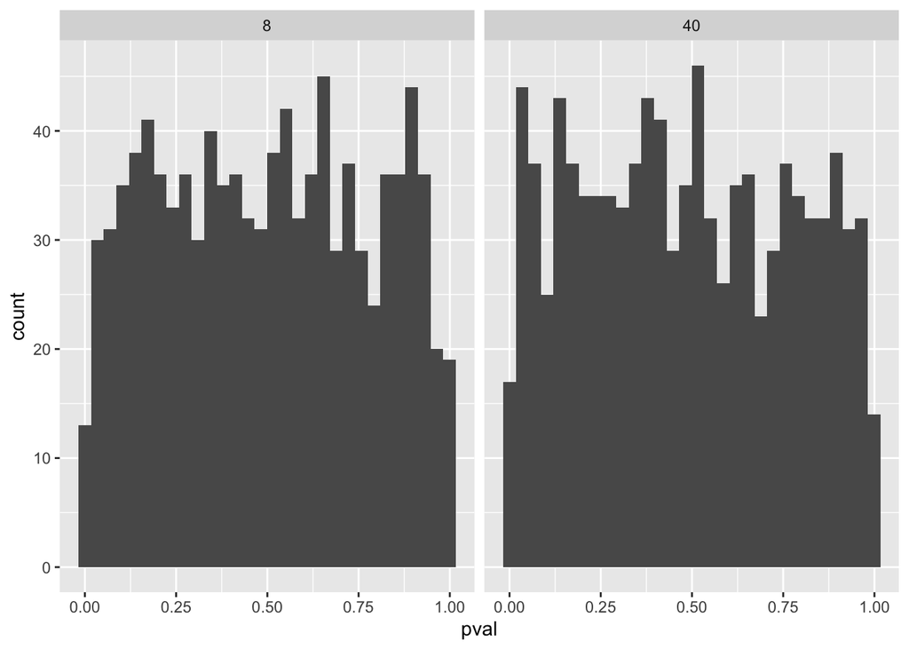

Beregner andelen tester under en bestemt p-verdi

```
## # A tibble: 2 × 2
##       n sig_results
##   <dbl>       <dbl>
## 1     8        0.04
## 2    40        0.06
```